# Tema 9: Graficos en R

Una vision practica a la visualizacion de datos

Rafael Puche & Fernando Hernandez

Julio de 2025

# Contenido

### Comandos basicos para Graficar

1. Sintaxis basica
2. Tipos de Plots
3. Uso de **`plot()`**, **`hist()`**, **`barplot()`**

### Nueva Generacion de graficos en R

1. Introduccion a ggplot2
2. Sintaxis y Ejemplos

### R base vs. ggplot2

1. Comparaciones
2. Sugerencias
3. Ejemplos

# Sugerencias

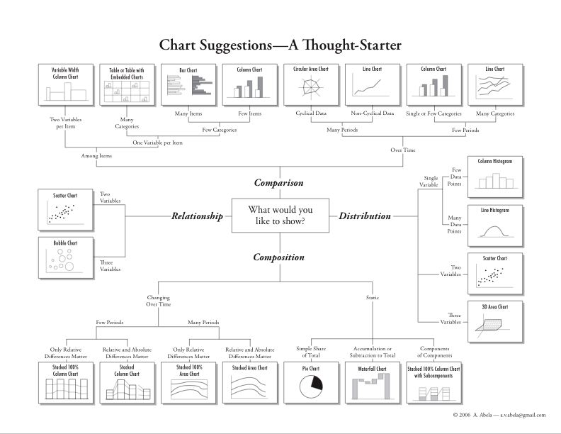

Panorama de Graficos

# Sintaxis basica

**Histograma**

`hist(vector_numerico,` `main = "Titulo del histograma",` `xlab = "Etiqueta del eje X",` `ylab = "Etiqueta del eje Y")`

**Grafico de Barras**

`barplot(vector_valores, main = "Título del grafico de barras", xlab = "Etiqueta del eje X", ylab = "Etiqueta del eje Y", names.arg = vector_categorias)`

# Sintaxis basica + `personalizacion`

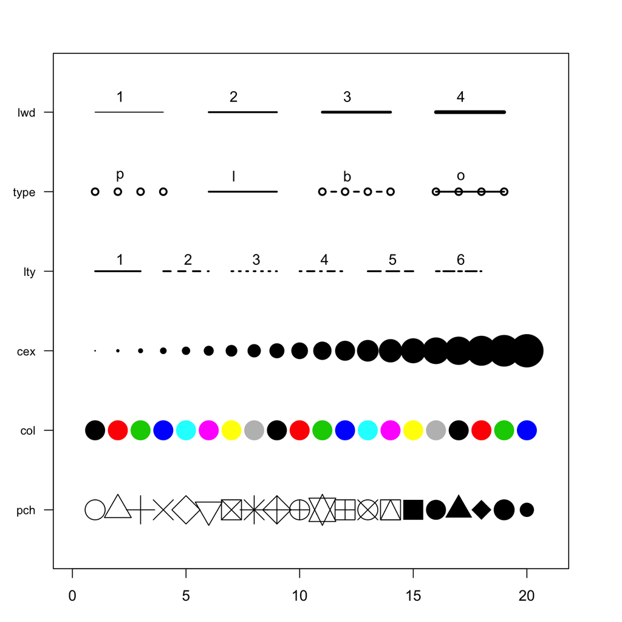

plot

# Tipos de Graficos: Los mas usados!

1. **Scatter Plot**: un vector que grafica X en funcion de Y **(dos variables continuas)**

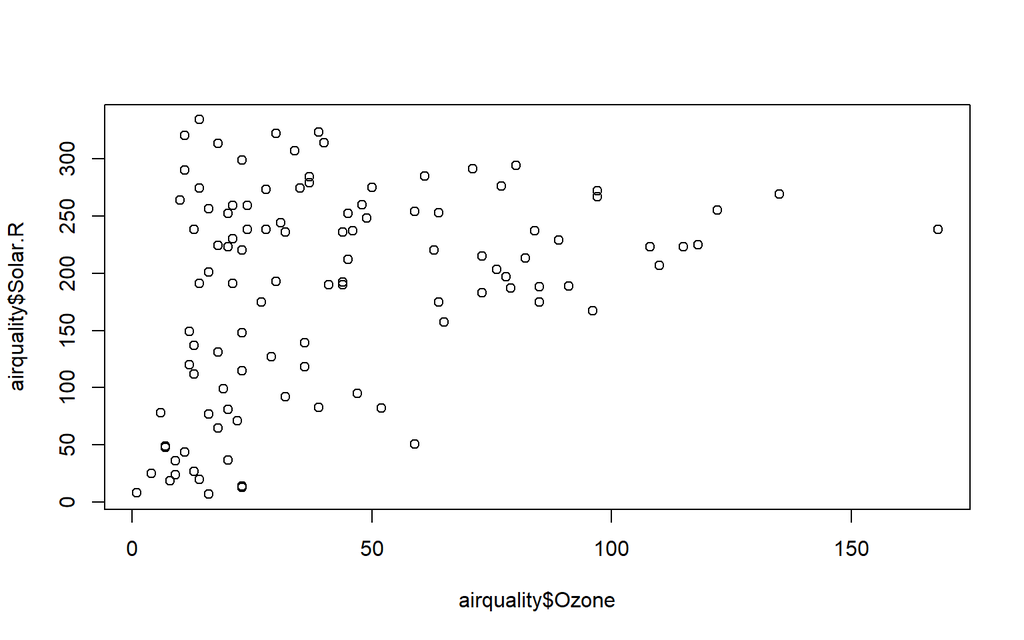

```r
data("airquality")
plot(airquality$Ozone, airquality$Solar.R)
```

# Tipos de Graficos (cont.)

2. **Line Graph**: un vector que grafica X en funcion de Y usando lineas

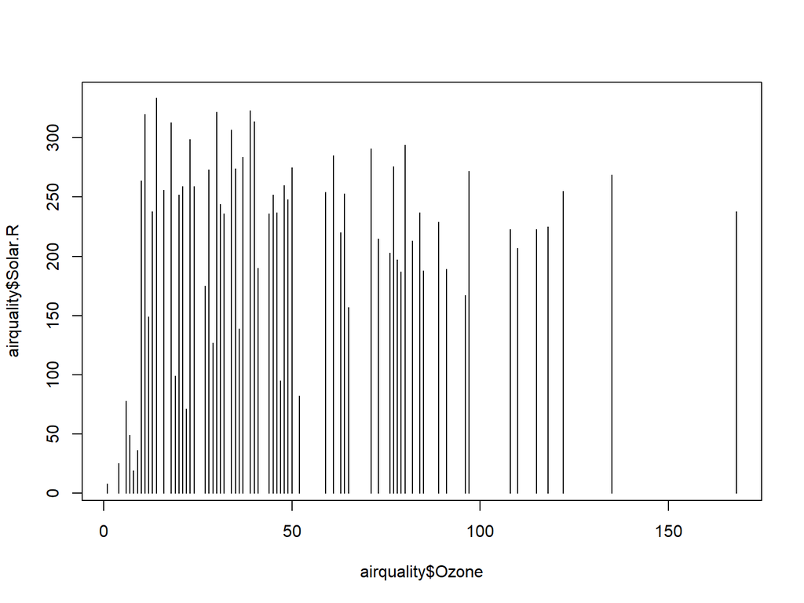

```r
data("airquality")
plot(airquality$Ozone, airquality$Solar.R, type = "h")
```

# Tipos de Graficos (cont.)

2.1 **Grafico de lineas**: un vector que grafica X en funcion de Y usando **lineas** **Cambiar la opcion `type`**

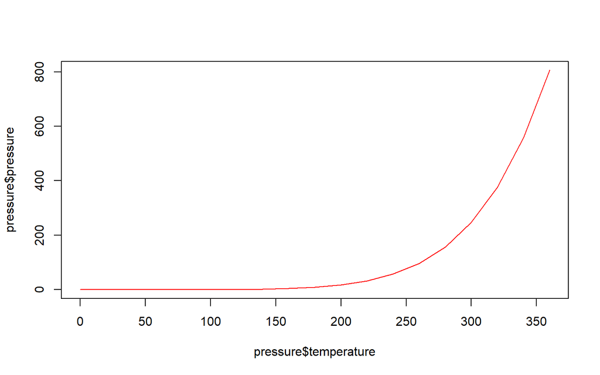

```r
data("pressure")
plot(pressure$temperature, pressure$pressure,
     type = "l",
     col="red")
```

# Tipos de Graficos (cont.)

2. **Bar Graph**: representar variables categoricas o discretas

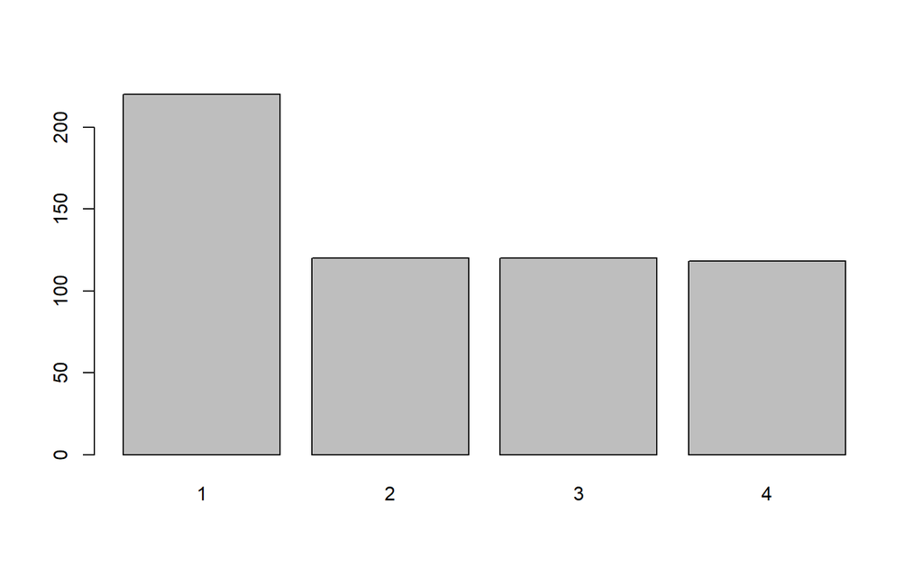

```r
barplot(table(ChickWeight$Diet))
```

# Tipos de Graficos (cont.)

3. **Histograma**: representar la frecuencia de las variables numéricas continuas

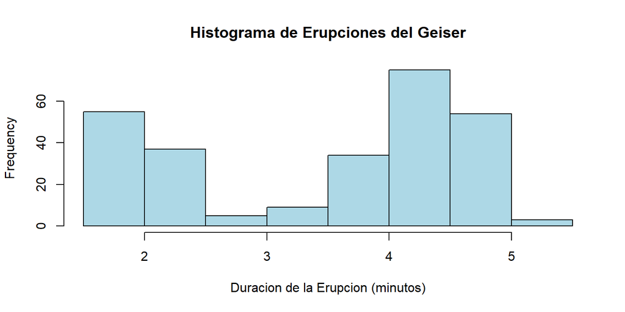

```r
hist(faithful$eruptions,
     main = "Histograma de Erupciones del Geiser",
     xlab = "Duracion de la Erupcion (minutos)",
     col = "lightblue")
```

# Tipos de Graficos (cont.)

3. **Pie Chart**: representa la cantidad de casos en cada categoria

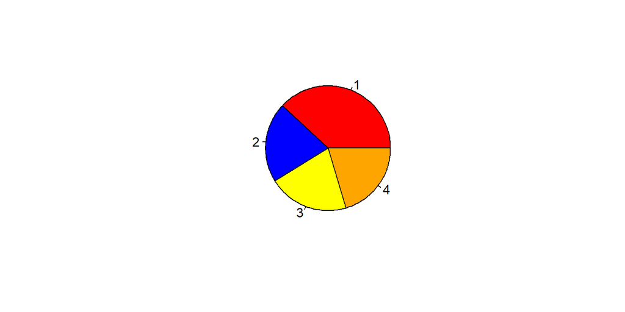

```r
pie(table(ChickWeight$Diet),
    col = c("red", "blue", "yellow", "orange"))
```

# Tipos de Graficos - Personalizando “Plots”

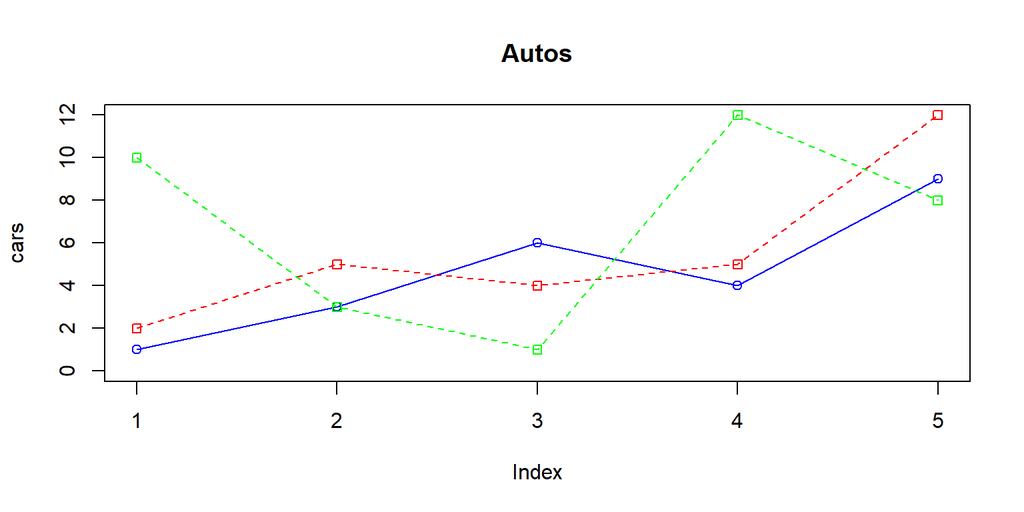

```r
cars <- c(1, 3, 6, 4, 9)
trucks <- c(2, 5, 4, 5, 12)
boats <- c(10,3,1,12,8)
plot(cars, type="o", col="blue", ylim=c(0,12))
lines(trucks, type="o", pch=22, lty=2, col="red")
lines(boats, type="o", pch=22, lty=2, col="green")
title(main="Autos", col.main="black", font.main=2)
```

# ggplot: “The grammar of graphics”

La idea basica: construir graficos segun las necesidades del usuario, a partir de bloques especificos.

### Los “bloques” o capas:

- **data**
- **aesthetic mapping**
- **geometric object**
- **faceting**
- statistical transformations
- scales
- coordinate system
- position adjustments

# Tabla Resumen de Capas en ggplot2

| Capa | Descripción Breve | Función de Ejemplo |
| --- | --- | --- |
| **Datos (Data)** | El `data.frame` que contiene la información a graficar. | `ggplot(data = ...)` |
| **Estéticas (Aesthetics)** | Conecta las variables de los datos con los atributos visuales (ejes, color, tamaño). | `aes(x = var1, y = var2)` |
| **Geometrías (Geometries)** | Define la forma visual que representan los datos (puntos, líneas, barras). | `geom_point()` |
| **Facetas (Facets)** | Divide el gráfico en múltiples sub-gráficos según una variable. | `facet_wrap(~ categoria)` |
| **Estadísticas (Stats)** | Realiza transformaciones estadísticas en los datos (ej. suavizado, conteo). | `stat_summary()` |
| **Escalas (Scales)** | Controla el mapeo de datos a la estética (ej. colores, ejes, leyendas). | `scale_color_viridis_d()` |
| **Coordenadas (Coords)** | Ajusta el sistema de coordenadas del gráfico (ej. invertir ejes). | `coord_flip()` |
| **Tema (Theme)** | Personaliza los elementos no relacionados con los datos (ej. fondo, fuentes). | `theme_minimal()` |

# Los “bloques” o capas + version grafica:

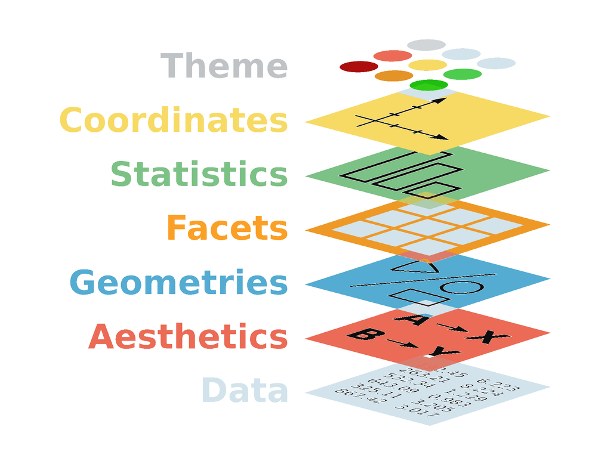

capas

# ggplot: Sintaxis

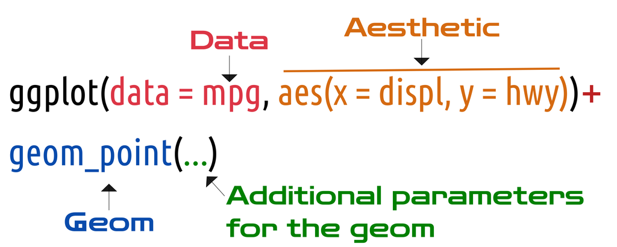

Sintaxtis de ggplot

# Tipos de Graficos en `ggplot`

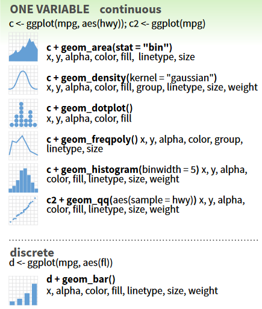

Basicos

# Tipos de Graficos en `ggplot`

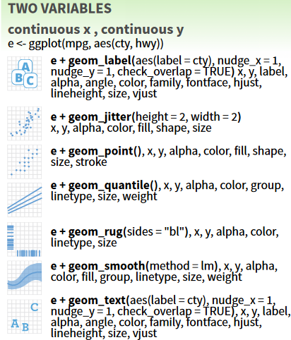

Basicos2

# Grafico de dispersion con “ChickenWeight” `paso` 1

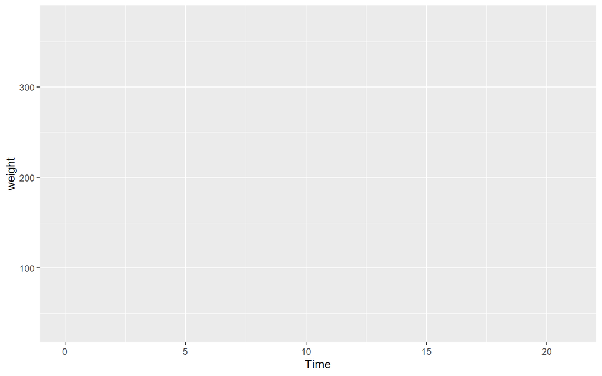

```r
library(ggplot2)
ggplot(ChickWeight, aes(Time, weight))
```

# Grafico de dispersion con “ChickenWeight” `paso` 2

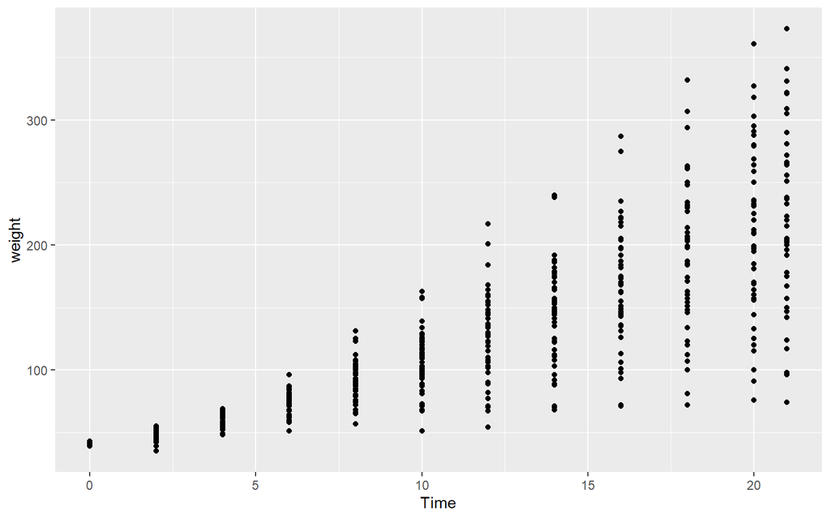

```r
library(ggplot2)
ggplot(ChickWeight, aes(Time, weight)) +
  geom_point()
```

# Grafico de dispersion con “ChickenWeight” `paso` 3

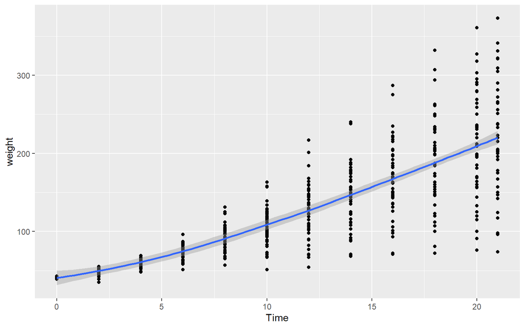

```r
library(ggplot2)
ggplot(ChickWeight, aes(Time, weight)) +
  geom_point() +
  geom_smooth()
```

# Grafico de dispersion con “ChickenWeight” + Dieta

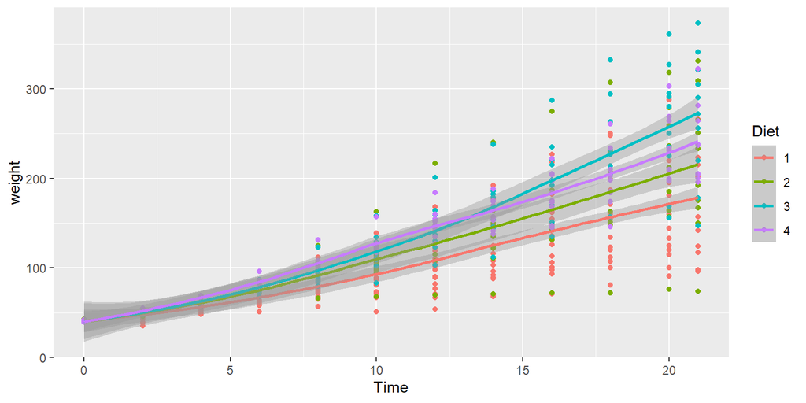

```r
library(ggplot2)
ggplot(ChickWeight, aes(Time, weight, colour=Diet)) +
  geom_point() +
  geom_smooth()
```

# Grafico de dispersion con “ChickenWeight” + Varios Graficos

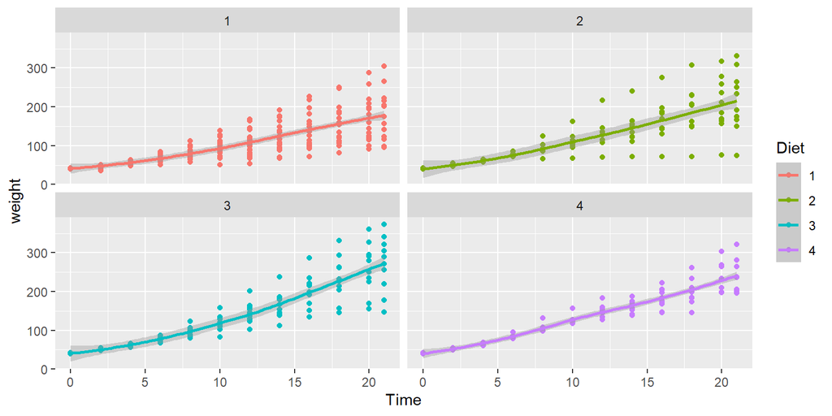

```r
library(ggplot2)
ggplot(ChickWeight, aes(Time, weight, colour=Diet)) +
  geom_point() +
  geom_smooth() +
  facet_wrap(~Diet)
```